# Graded python project

```python
import pandas as pd
```

```python
df=pd.read_csv(r"C:\Users\Manohar\Downloads\youtube_dislike_dataset.csv")
```

```python
df
```

|  | video_id | title | channel_id | channel_title | published_at | view_count | likes | dislikes | comment_count | tags | description | comments |
| --- | --- | --- | --- | --- | --- | --- | --- | --- | --- | --- | --- | --- |
| 0 | --0bCF-iK2E | Jadon Sancho Magical Skills & Goals | UC6UL29enLNe4mqwTfAyeNuw | Bundesliga | 2021-07-01 10:00:00 | 1048888 | 19515 | 226 | 1319 | football soccer ftbol alemn Bundesliga season ... | Enjoy the best skills and goals from Jadon San... | Respect to Dortmund fans,must be sad losing hi... |
| 1 | --14w5SOEUs | Migos - Avalanche (Official Video) | UCGIelM2Dj3zza3xyV3pL3WQ | MigosVEVO | 2021-06-10 16:00:00 | 15352638 | 359277 | 7479 | 18729 | Migos Avalanche Quality Control Music/Motown R... | Watch the the official video for Migos - "Aval... | Migos just makes me want to live my live to th... |
| 2 | --40TEbZ9Is | Supporting Actress in a Comedy: 73rd Emmys | UClBKH8yZRcM4AsRjDVEdjMg | Television Academy | 2021-09-20 01:03:32 | 925281 | 11212 | 401 | 831 |  | Hannah Waddingham wins the Emmy for Supporting... | Hannah's energy bursts through any screen. Wel... |
| 3 | --4tfbSyYDE | JO1'YOUNG (JO1 ver.)' PERFORMANCE VIDEO | UCsmXiDP8S40uBeJYxvyulmA | JO1 | 2021-03-03 10:00:17 | 2641597 | 39131 | 441 | 3745 | PRODUCE101JAPAN JO1 TheSTAR STA... | JO1'YOUNG (JO1 ver.)' PERFORMANCE VIDEO\n\n---... | youngVer>< REN is really PERFECT. It's not ju... |
| 4 | --DKkzWVh-E | Why Retaining Walls Collapse | UCMOqf8ab-42UUQIdVoKwjlQ | Practical Engineering | 2021-12-07 13:00:00 | 715724 | 32887 | 367 | 1067 | retaining wall New Jersey highway Direct Conne... | One of the most important (and innocuous) part... | Keep up with all my projects here: https://pr... |
| ... | ... | ... | ... | ... | ... | ... | ... | ... | ... | ... | ... | ... |
| 37417 | zzd4ydafGR0 | Lil Tjay - Calling My Phone (feat. 6LACK) [Off... | UCEB4a5o_6KfjxHwNMnmj54Q | Lil Tjay | 2021-02-12 05:03:49 | 120408275 | 2180780 | 35871 | 81360 | Lil Tjay Steady Calling My Phone Calling My Ph... | Official video for "Calling My Phone" by Lil T... | 'DESTINED 2 WIN' OUT NOW !! https://liltjay.ln... |
| 37418 | zziBybeSAtw | PELICANS at LAKERS \| FULL GAME HIGHLIGHTS \| Ja... | UCWJ2lWNubArHWmf3FIHbfcQ | NBA | 2021-01-16 05:39:05 | 2841917 | 20759 | 1049 | 2624 | NBA G League Basketball game-0022000187 Lakers... | PELICANS at LAKERS \| FULL GAME HIGHLIGHTS \| Ja... | Montrezl Harrell is going crazy with the rebou... |
| 37419 | zzk09ESX7e0 | [MV] (MAMAMOO) - Where Are We Now | UCuhAUMLzJxlP1W7mEk0_6lA | MAMAMOO | 2021-06-02 09:00:10 | 13346678 | 720854 | 4426 | 90616 | MAMAMOO WAW WAW MAMAMOO WAW Where Are We Now... | [MV] (MAMAMOO) - Where Are We Now\n\nInstagra... | I honestly do not know why this song hit so ha... |
| 37420 | zzmQEb0Em5I | FELLIPE ESCUDERO- Master Podcast #12 | UC8NjnNWMsRqq11NYvHAQb1g | Master Podcast | 2020-10-20 20:59:30 | 252057 | 19198 | 1234 | 1471 | master masterpodcast lord lord vinheteiro z z ... | DOCTOR HAIR\nhttps://www.thedoctorhair.com/?fb... | Foi um prazer passar esta tarde com vocs debat... |
| 37421 | zzxPZwaA-8w | Gareth Bale brace secures dramatic comeback on... | UCEg25rdRZXg32iwai6N6l0w | Tottenham Hotspur | 2021-05-23 21:00:31 | 2252090 | 34063 | 868 | 2004 | Spurs Tottenham Hotspur Tottenham Leicester ... | Two minute highlights from Tottenham Hotspur's... | Thank you Kane for everything you have given t... |

37422 rows × 12 columns

1. Import required libraries and read the provided dataset (youtube_dislike_dataset.csv) and retrieve top 5 and bottom 5 records. (3 marks)

```python
df.head(5)
```

|  | video_id | title | channel_id | channel_title | published_at | view_count | likes | dislikes | comment_count | tags | description | comments |
| --- | --- | --- | --- | --- | --- | --- | --- | --- | --- | --- | --- | --- |
| 0 | --0bCF-iK2E | Jadon Sancho Magical Skills & Goals | UC6UL29enLNe4mqwTfAyeNuw | Bundesliga | 2021-07-01 10:00:00 | 1048888 | 19515 | 226 | 1319 | football soccer ftbol alemn Bundesliga season ... | Enjoy the best skills and goals from Jadon San... | Respect to Dortmund fans,must be sad losing hi... |
| 1 | --14w5SOEUs | Migos - Avalanche (Official Video) | UCGIelM2Dj3zza3xyV3pL3WQ | MigosVEVO | 2021-06-10 16:00:00 | 15352638 | 359277 | 7479 | 18729 | Migos Avalanche Quality Control Music/Motown R... | Watch the the official video for Migos - "Aval... | Migos just makes me want to live my live to th... |
| 2 | --40TEbZ9Is | Supporting Actress in a Comedy: 73rd Emmys | UClBKH8yZRcM4AsRjDVEdjMg | Television Academy | 2021-09-20 01:03:32 | 925281 | 11212 | 401 | 831 |  | Hannah Waddingham wins the Emmy for Supporting... | Hannah's energy bursts through any screen. Wel... |
| 3 | --4tfbSyYDE | JO1'YOUNG (JO1 ver.)' PERFORMANCE VIDEO | UCsmXiDP8S40uBeJYxvyulmA | JO1 | 2021-03-03 10:00:17 | 2641597 | 39131 | 441 | 3745 | PRODUCE101JAPAN JO1 TheSTAR STA... | JO1'YOUNG (JO1 ver.)' PERFORMANCE VIDEO\n\n---... | youngVer>< REN is really PERFECT. It's not ju... |
| 4 | --DKkzWVh-E | Why Retaining Walls Collapse | UCMOqf8ab-42UUQIdVoKwjlQ | Practical Engineering | 2021-12-07 13:00:00 | 715724 | 32887 | 367 | 1067 | retaining wall New Jersey highway Direct Conne... | One of the most important (and innocuous) part... | Keep up with all my projects here: https://pr... |

```python
df.tail(5)
```

|  | video_id | title | channel_id | channel_title | published_at | view_count | likes | dislikes | comment_count | tags | description | comments |
| --- | --- | --- | --- | --- | --- | --- | --- | --- | --- | --- | --- | --- |
| 37417 | zzd4ydafGR0 | Lil Tjay - Calling My Phone (feat. 6LACK) [Off... | UCEB4a5o_6KfjxHwNMnmj54Q | Lil Tjay | 2021-02-12 05:03:49 | 120408275 | 2180780 | 35871 | 81360 | Lil Tjay Steady Calling My Phone Calling My Ph... | Official video for "Calling My Phone" by Lil T... | 'DESTINED 2 WIN' OUT NOW !! https://liltjay.ln... |
| 37418 | zziBybeSAtw | PELICANS at LAKERS \| FULL GAME HIGHLIGHTS \| Ja... | UCWJ2lWNubArHWmf3FIHbfcQ | NBA | 2021-01-16 05:39:05 | 2841917 | 20759 | 1049 | 2624 | NBA G League Basketball game-0022000187 Lakers... | PELICANS at LAKERS \| FULL GAME HIGHLIGHTS \| Ja... | Montrezl Harrell is going crazy with the rebou... |
| 37419 | zzk09ESX7e0 | [MV] (MAMAMOO) - Where Are We Now | UCuhAUMLzJxlP1W7mEk0_6lA | MAMAMOO | 2021-06-02 09:00:10 | 13346678 | 720854 | 4426 | 90616 | MAMAMOO WAW WAW MAMAMOO WAW Where Are We Now... | [MV] (MAMAMOO) - Where Are We Now\n\nInstagra... | I honestly do not know why this song hit so ha... |
| 37420 | zzmQEb0Em5I | FELLIPE ESCUDERO- Master Podcast #12 | UC8NjnNWMsRqq11NYvHAQb1g | Master Podcast | 2020-10-20 20:59:30 | 252057 | 19198 | 1234 | 1471 | master masterpodcast lord lord vinheteiro z z ... | DOCTOR HAIR\nhttps://www.thedoctorhair.com/?fb... | Foi um prazer passar esta tarde com vocs debat... |
| 37421 | zzxPZwaA-8w | Gareth Bale brace secures dramatic comeback on... | UCEg25rdRZXg32iwai6N6l0w | Tottenham Hotspur | 2021-05-23 21:00:31 | 2252090 | 34063 | 868 | 2004 | Spurs Tottenham Hotspur Tottenham Leicester ... | Two minute highlights from Tottenham Hotspur's... | Thank you Kane for everything you have given t... |

2. Check the info of the dataframe and write your inferences on data types and shape of the dataset. (3 marks)

```python
df.shape
```

```
(37422, 12)
```

```python
df.info()
```

```
<class 'pandas.core.frame.DataFrame'>
RangeIndex: 37422 entries, 0 to 37421
Data columns (total 12 columns):
 #   Column         Non-Null Count  Dtype
---  ------         --------------  -----
 0   video_id       37422 non-null  object
 1   title          37422 non-null  object
 2   channel_id     37422 non-null  object
 3   channel_title  37422 non-null  object
 4   published_at   37422 non-null  object
 5   view_count     37422 non-null  int64
 6   likes          37422 non-null  int64
 7   dislikes       37422 non-null  int64
 8   comment_count  37422 non-null  int64
 9   tags           37422 non-null  object
 10  description    37422 non-null  object
 11  comments       37264 non-null  object
dtypes: int64(4), object(8)
memory usage: 3.4+ MB
```

3. Check for the Percentage of the missing values and drop or impute them. (3 marks)

```python
df.isnull().sum()
```

```
video_id           0
title              0
channel_id         0
channel_title      0
published_at       0
view_count         0
likes              0
dislikes           0
comment_count      0
tags               0
description        0
comments         158
dtype: int64
```

4. Check the statistical summary of both numerical and categorical columns and write your inferences. (5 marks)

```python
df.describe()
```

|  | view_count | likes | dislikes | comment_count |
| --- | --- | --- | --- | --- |
| count | 3.742200e+04 | 3.742200e+04 | 3.742200e+04 | 3.742200e+04 |
| mean | 5.697838e+06 | 1.668147e+05 | 4.989862e+03 | 9.924930e+03 |
| std | 2.426622e+07 | 5.375670e+05 | 3.070824e+04 | 1.171003e+05 |
| min | 2.036800e+04 | 0.000000e+00 | 0.000000e+00 | 0.000000e+00 |
| 25% | 5.122970e+05 | 1.323350e+04 | 2.810000e+02 | 9.000000e+02 |
| 50% | 1.319078e+06 | 4.233050e+04 | 7.960000e+02 | 2.328000e+03 |
| 75% | 3.670231e+06 | 1.304698e+05 | 2.461750e+03 | 6.184000e+03 |
| max | 1.322797e+09 | 3.183768e+07 | 2.397733e+06 | 1.607103e+07 |

5. Convert datatype of column published_at from object to pandas datetime. (5 marks)

```python
df["published_at"]=pd.to_datetime(df["published_at"],utc=True)
df.dtypes
```

```
video_id                      object
title                         object
channel_id                    object
channel_title                 object
published_at     datetime64[ns, UTC]
view_count                     int64
likes                          int64
dislikes                       int64
comment_count                  int64
tags                          object
description                   object
comments                      object
dtype: object
```

6. Create a new column as 'published_month' using the column published_at (display the months only) (3 marks)

```python
df["month"]=df["published_at"].dt.month
```

```python
df.head()
```

|  | video_id | title | channel_id | channel_title | published_at | view_count | likes | dislikes | comment_count | tags | description | comments | month |
| --- | --- | --- | --- | --- | --- | --- | --- | --- | --- | --- | --- | --- | --- |
| 0 | --0bCF-iK2E | Jadon Sancho Magical Skills & Goals | UC6UL29enLNe4mqwTfAyeNuw | Bundesliga | 2021-07-01 10:00:00+00:00 | 1048888 | 19515 | 226 | 1319 | football soccer ftbol alemn Bundesliga season ... | Enjoy the best skills and goals from Jadon San... | Respect to Dortmund fans,must be sad losing hi... | 7 |
| 1 | --14w5SOEUs | Migos - Avalanche (Official Video) | UCGIelM2Dj3zza3xyV3pL3WQ | MigosVEVO | 2021-06-10 16:00:00+00:00 | 15352638 | 359277 | 7479 | 18729 | Migos Avalanche Quality Control Music/Motown R... | Watch the the official video for Migos - "Aval... | Migos just makes me want to live my live to th... | 6 |
| 2 | --40TEbZ9Is | Supporting Actress in a Comedy: 73rd Emmys | UClBKH8yZRcM4AsRjDVEdjMg | Television Academy | 2021-09-20 01:03:32+00:00 | 925281 | 11212 | 401 | 831 |  | Hannah Waddingham wins the Emmy for Supporting... | Hannah's energy bursts through any screen. Wel... | 9 |
| 3 | --4tfbSyYDE | JO1'YOUNG (JO1 ver.)' PERFORMANCE VIDEO | UCsmXiDP8S40uBeJYxvyulmA | JO1 | 2021-03-03 10:00:17+00:00 | 2641597 | 39131 | 441 | 3745 | PRODUCE101JAPAN JO1 TheSTAR STA... | JO1'YOUNG (JO1 ver.)' PERFORMANCE VIDEO\n\n---... | youngVer>< REN is really PERFECT. It's not ju... | 3 |
| 4 | --DKkzWVh-E | Why Retaining Walls Collapse | UCMOqf8ab-42UUQIdVoKwjlQ | Practical Engineering | 2021-12-07 13:00:00+00:00 | 715724 | 32887 | 367 | 1067 | retaining wall New Jersey highway Direct Conne... | One of the most important (and innocuous) part... | Keep up with all my projects here: https://pr... | 12 |

7. Replace the numbers in the column published_month as names of the months i,e., 1 as 'Jan', 2 as 'Feb' and so on..... (5 marks)

```python
df["Month_Name"]=df["published_at"].dt.month_name()
```

```python
df.head(1)
```

|  | video_id | title | channel_id | channel_title | published_at | view_count | likes | dislikes | comment_count | tags | description | comments | month | Month_Name |
| --- | --- | --- | --- | --- | --- | --- | --- | --- | --- | --- | --- | --- | --- | --- |
| 0 | --0bCF-iK2E | Jadon Sancho Magical Skills & Goals | UC6UL29enLNe4mqwTfAyeNuw | Bundesliga | 2021-07-01 10:00:00+00:00 | 1048888 | 19515 | 226 | 1319 | football soccer ftbol alemn Bundesliga season ... | Enjoy the best skills and goals from Jadon San... | Respect to Dortmund fans,must be sad losing hi... | 7 | July |

8. Find the number of videos published each month and arrange the months in a decreasing order based on the video count. (5 marks)

```python
df[["Month_Name","video_id"]].groupby("Month_Name").count().sort_values(by="video_id",ascending=False)
```

| Month_Name | video_id |
| --- | --- |
| October | 4991 |
| September | 4880 |
| November | 4851 |
| August | 4262 |
| December | 3072 |
| July | 2340 |
| June | 2316 |
| March | 2258 |
| February | 2137 |
| April | 2126 |
| January | 2108 |
| May | 2081 |

9. Find the count of unique video_id, channel_id and channel_title. (3 marks)

```python
print("video_Id : ",df["video_id"].nunique())
```

```
video_Id :  37422
```

```python
df.columns
```

```
Index(['video_id', 'title', 'channel_id', 'channel_title', 'published_at',
       'view_count', 'likes', 'dislikes', 'comment_count', 'tags',
       'description', 'comments', 'month', 'Month_Name'],
      dtype='object')
```

```python
print("channel_id :",df["channel_id"].nunique())
```

```
channel_id : 10961
```

```python
print("channel_title:",df["channel_title"].nunique())
```

```
channel_title: 10883
```

10. Find the top10 channel names having the highest number of videos in the dataset and the bottom10 having lowest number of videos. (3 marks)

```python
df["channel_title"].value_counts().head(10)
```

```
channel_title
Sky Sports Football    533
The United Stand       301
BT Sport               246
NBA                    209
NFL                    162
WWE                    122
SSSniperWolf            99
SSundee                 98
FORMULA 1               87
NHL                     86
Name: count, dtype: int64
```

```python
df["channel_title"].value_counts().tail(10)
```

```
channel_title
Eiaz                     1
adidas                   1
Universitetet i Agder    1
Team Tapia               1
TheVincentMottola        1
Blocktrainer             1
Movie Addicts            1
1 1 minute mom           1
FLORIN CERCEL            1
Master Podcast           1
Name: count, dtype: int64
```

11. Find the title of the video which has the maximum number of likes and the title of the video having minimum likes and write your inferences. (3 marks)

```python
df[df['likes']==max(df['likes'])][['title']]
```

|  | title |
| --- | --- |
| 26143 | BTS () 'Dynamite' Official MV |

```python
df[df['likes']==min(df['likes'])][['title']]
```

|  | title |
| --- | --- |
| 18654 | Kim Kardashian's Must-See Moments on "Saturday... |

12. Find the title of the video which has the maximum number of dislikes and the title of the video having minimum dislikes and write your inferences. (3 marks)

```python
df[df['dislikes']==max(df['dislikes'])][['title']]
```

|  | title |
| --- | --- |
| 13591 | Cuties \| Official Trailer \| Netflix |

```python
df[df['dislikes']==min(df['dislikes'])][['title']]
```

|  | title |
| --- | --- |
| 18654 | Kim Kardashian's Must-See Moments on "Saturday... |

13. Does the number of views have any effect on how many people disliked the video? Support your answer with a metric and a plot. (3 marks)

```python
import matplotlib.pyplot as plt
import seaborn as sns
```

```python
correlation_view_dislikes = df['view_count'].corr(df['dislikes'])
print(f"Correlation between view_count and dislikes: {correlation_view_dislikes}")
```

```
Correlation between view_count and dislikes: 0.6844687753905547
```

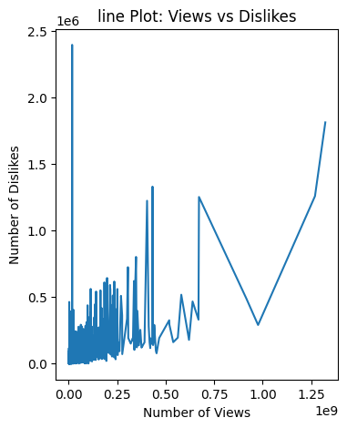

```python
plt.figure(figsize=(4, 5,))
sns.lineplot(x='view_count', y='dislikes', data=df)
plt.title('line Plot: Views vs Dislikes')
plt.xlabel('Number of Views')
plt.ylabel('Number of Dislikes')
plt.show()
```

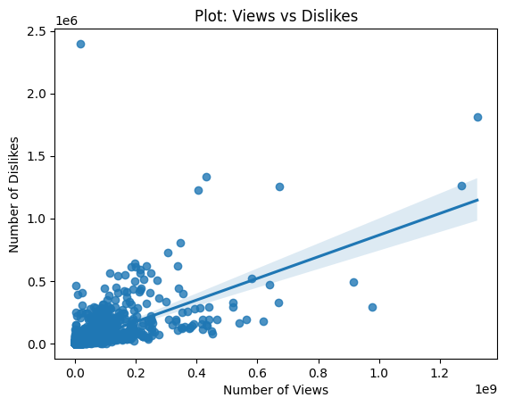

```python
sns.regplot(x='view_count',y='dislikes',data=df)
plt.title('Plot: Views vs Dislikes')
plt.xlabel('Number of Views')
plt.ylabel('Number of Dislikes')
plt.show()
```

14. Display all the information about the videos that were published in January, and mention the count of videos that were published in January.

df[df['Month_Name']=='January']

```python
df[df['Month_Name']=='January'][['Month_Name']].count()
```

```
Month_Name    2108
dtype: int64
```

```
                " PROJECT COMPLETED "
```